# scRNA Seq Seurat Tutorial

2025-04-08

Tyler Jensen

- Post-running Wrapper Script
- Scaling Data
- Run PCA with Variable Features
- Determining how many PCs to include in analysis
- Clustering the cells
  - Finding neighbors and clusters
  - Running tSNE and/or UMAP
- MAST - Finding Markers and Differential Expression Analysis
  - Before MAST:
  - Finding Markers
  - Visualizing the Marker Expression

## Post-running Wrapper Script

At this point you should have ran the Seurat portion of the wrapper script, which saves an RData file containing a Seurat object post-integration of all samples. Load in the RData file and you can get started with the rest of the Seurat pipeline.

## Scaling Data

Scaling the data is applying a linear transformation and can be used with the default parameters unless you want to scale all the features, not just the variable features.

**Make sure the default assay is set to integrated.**

```r
DefaultAssay(mice.combined) <- "integrated"
```

Scale the data with defaults.

```r
mice.combined <- ScaleData(object = mice.combined)
```

## Run PCA with Variable Features

The features used to perform PCA are by default the variable features chosen before (this was in the Seurat script ran previously). But if you want to choose a subset to find variable features off of instead, this can be specified with the features parameter.

```r
mice.combined <- RunPCA(mice.combined, features = VariableFeatures(object = mice.combined))
```

This will print out the first five features from the first five principal components.

```r
print(mice.combined[["pca"]], dims = 1:5, nfeatures = 5)
```

```
## PC_ 1
## Positive:  Ly6c1, Cldn5, Igfbp7, Slco1a4, Abcb1a
## Negative:  Ctss, Cd74, Cd52, Tyrobp, Cd14
## PC_ 2
## Positive:  Gpm6b, Ckb, Htra1, Itih3, Fez1
## Negative:  Ly6a, Cldn5, Ier3, Klf2, Slco1a4
## PC_ 3
## Positive:  Cldn11, Gjb1, Gm21984, Mbp, Ermn
## Negative:  Id4, Mt3, Gpm6a, Gpr37l1, Apoe
## PC_ 4
## Positive:  Slc1a3, Gpr37l1, Itih3, Ntsr2, Scg3
## Negative:  1500015O10Rik, Kl, Ttr, Spag6l, Sostdc1
## PC_ 5
## Positive:  Lgals3, Tgfbi, Wfdc17, Ly6c2, S100a11
## Negative:  C1qa, Crybb1, Hexb, Ccl12, P2ry12
```

VizDimLoadings(), DimPlot(), DimHeatmap() can be used to look at cells and features that define the PCA.

VizDimLoadings() shows each feature (gene) within the PC and whether or not it is correlated (positive loading) within the PC.

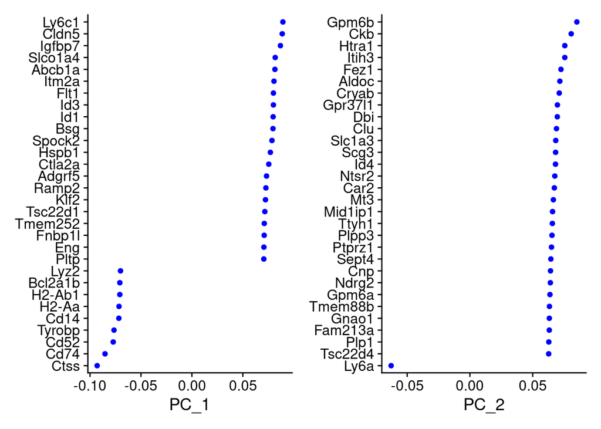

```r
VizDimLoadings(mice.combined, dims = 1:2, reduction = "pca")
```

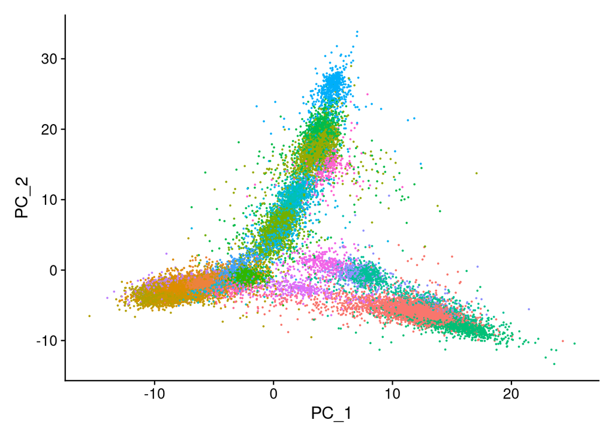

```r
DimPlot(mice.combined, reduction = "pca") + NoLegend()
```

DimHeatmap() is nice because you can see the different sources of heterogeneity in the data. The cells parameter will plot the extreme positive and negative cells. You can set however many PCs you want to look at, I am just showing 2 here.

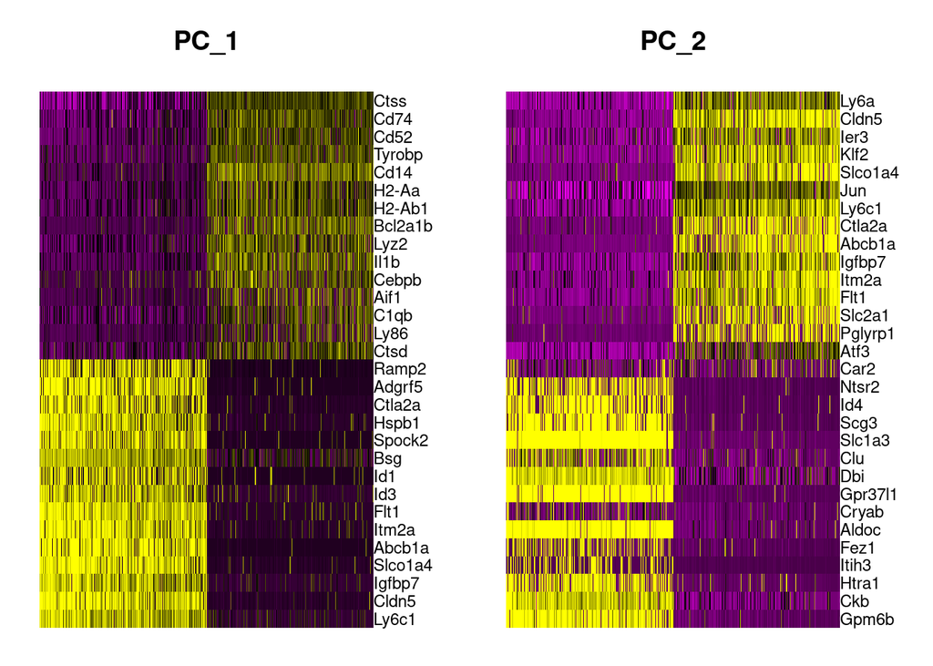

```r
DimHeatmap(mice.combined, dims = 1:2, cells = 500, balanced = TRUE)
```

## Determining how many PCs to include in analysis

Each PC captures as much variation in the data as possible, with only each PC explaining a portion of the total variance. The first PC always captures the most variance and the second captures most remaining variance, and so on. However, at some point adding more PCs gives you only a bit more information, but not enough to include.

An Elbow Plot can help determine how many PCs to include in the downstream analysis. It plots the number of PCs vs. the variance explained. Wherever the “elbow” or plateau is in the plot, is how many PCs you want to pick. It is generally recommended to not pick less than 5 PCs.

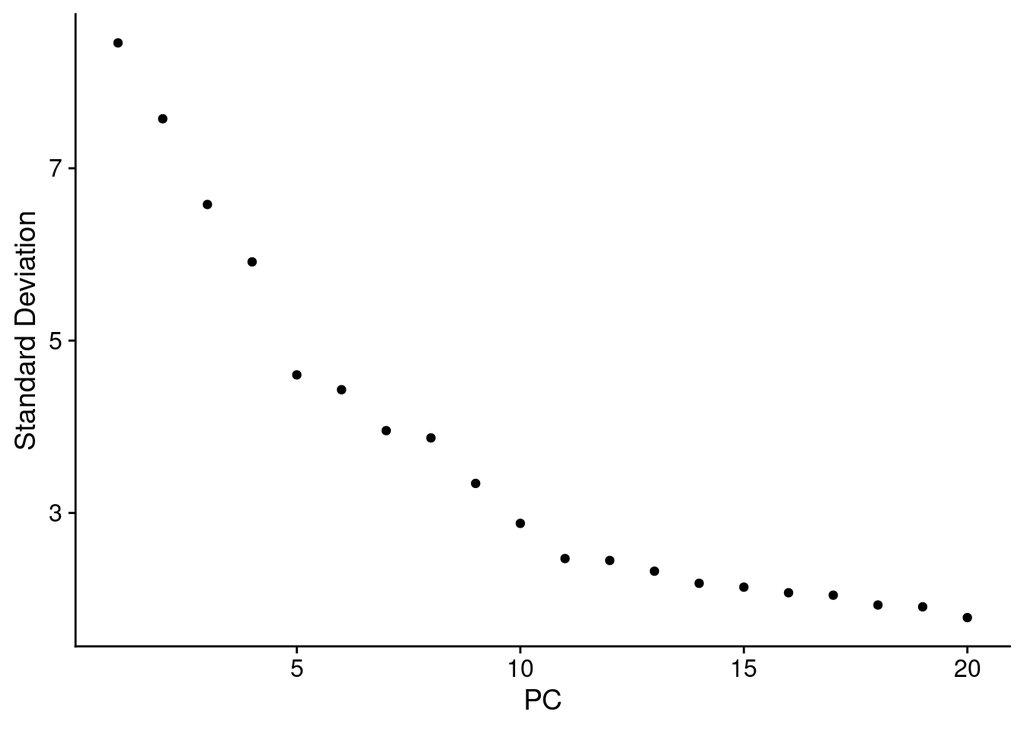

```r
ElbowPlot(mice.combined)
```

In this plot, I would shoot for something between 15 and 20.

**Usually running PCA takes a bit of time depending on how large the Seurat object is. If it is taking awhile, I would recommend saving the Seurat object and anything else important to an .RData file using the save() command. This way you won’t have to run PCA again if you need to come back later.**

## Clustering the cells

### Finding neighbors and clusters

Seurat uses a graph-based clustering method by calculating the distance between cells using the PCs, then making a KNN graph where edges connect similar cells. Clustering is then performed using algorithms like Louvain (default) or SLM. You can control the granularity at which you want to cluster the cells as well with the resolution parameter. Typical range for ~3,000 cells is 0.4-1.2. If you get less clusters than expected, you can increase the resolution.

```r
# In this example I am using 1-15 PCs (first 15 PCs)
mice.combined <- FindNeighbors(mice.combined, reduction = "pca", dims = 1:15)

mice.combined <- FindClusters(mice.combined, resolution = 0.5)
```

### Running tSNE and/or UMAP

Seurat provides non-linear dimensional reduction methods like tSNE and UMAP that group similar cells in a low-dimensional space. tSNE is good at preserving local structure (more fine-grain information) and UMAP is good at preserving global structure, which may offer more interpretable visualizations. If you want to reveal clusters and look more at local structure, tSNE is the better option, but if you more so want to explore the overall structure UMAP is better.

```r
# tSNE
mice.combined <- RunTSNE(mice.combined, reduction = "pca", dims = 1:15)

# UMAP
mice.combined <- RunUMAP(mice.combined, reduction = "pca", dims = 1:15)
```

You can then visualize the clusters using DimPlot(). I will show the tSNE reduction only.

You can also label each individual cluster depending on the metadata provided prior to integration (this is in the wrapper script).

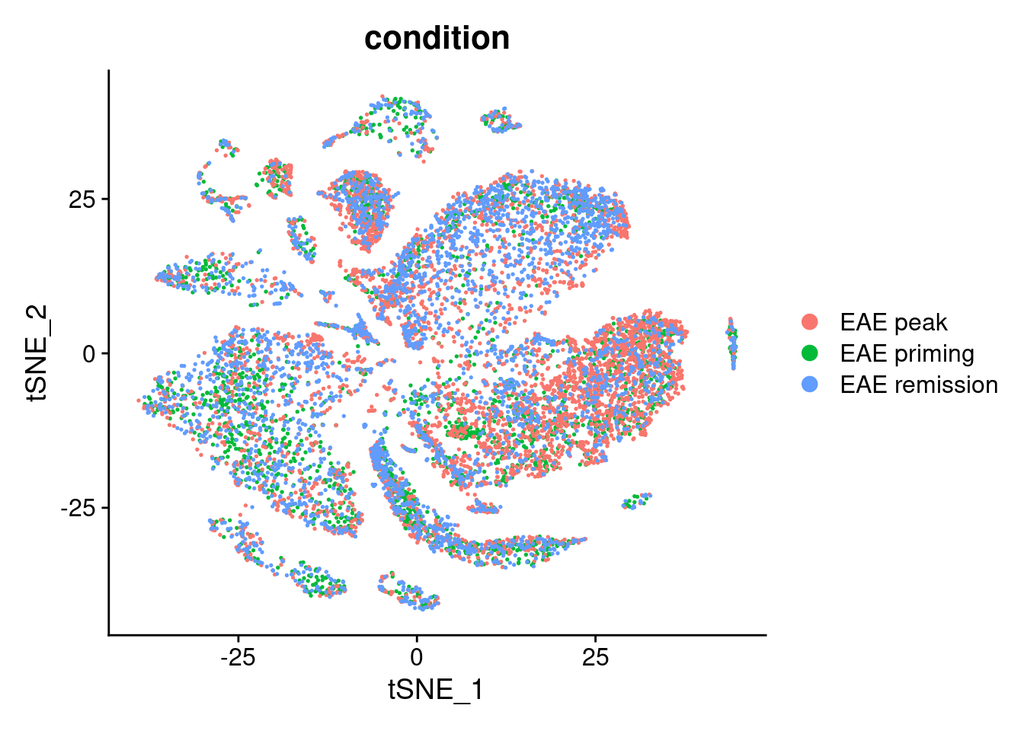

```r
# this looks at only the mice with EAE in the condition name, but this could be changed depending on the condition you are looking at
p1 <- DimPlot(subset(mice.combined, subset = condition %in% c("EAE priming", "EAE remission", "EAE peak")),
              reduction = "tsne", group.by = "condition")
# this plot groups by condition (provided from metadata in wrapper) using tSNE
p2 <- DimPlot(mice.combined, reduction = "tsne", group.by = "condition")
# this plot is using tSNE reduction with no other parameters
p3 <- DimPlot(mice.combined, reduction = "tsne", group.by = "seurat_clusters")

p1
```

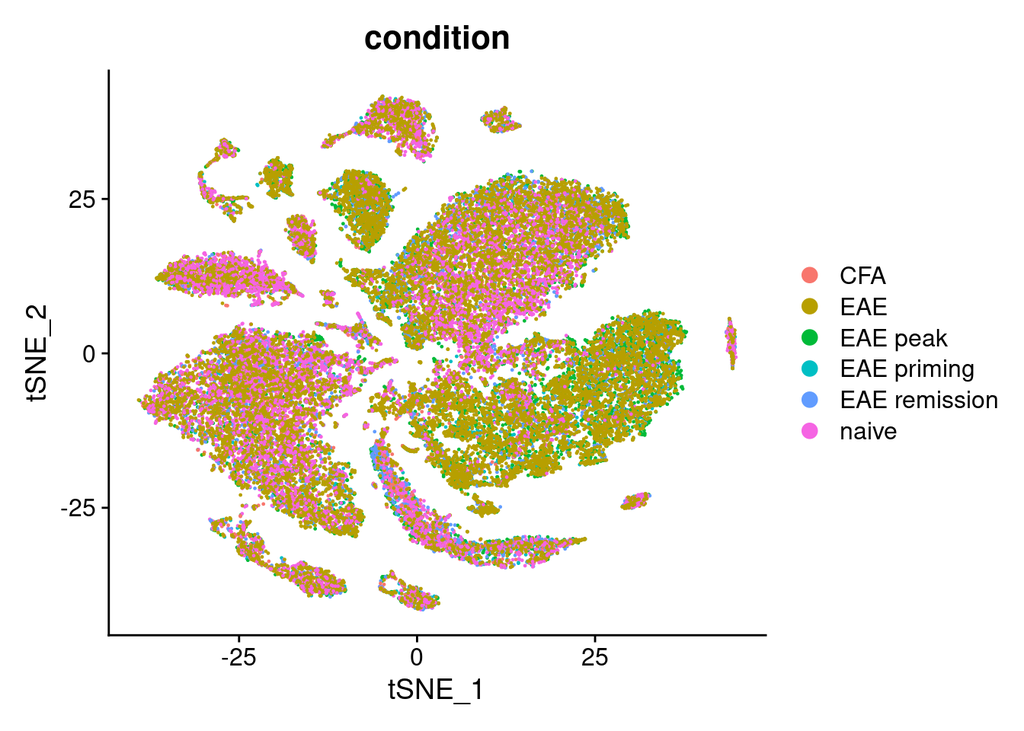

```r
p2
```

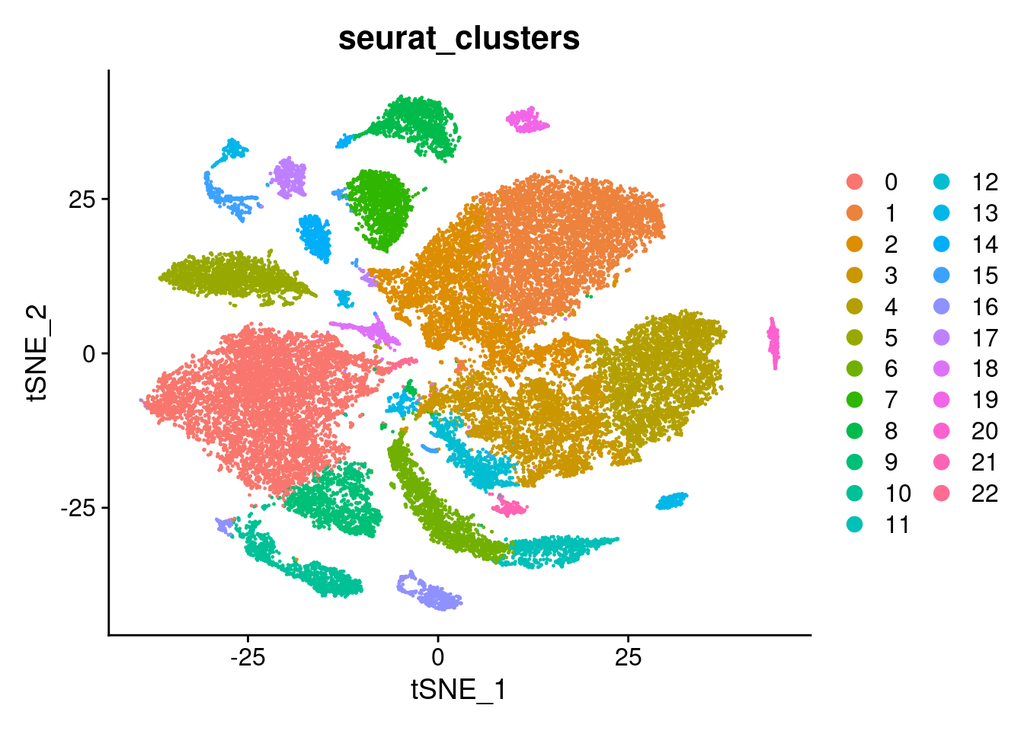

```r
p3
```

**Here I would also save the Seurat object since clustering is finished. Make sure each RData file is named something different so nothing is overwritten.**

## MAST - Finding Markers and Differential Expression Analysis

### Before MAST:

1. The active identity of the Seurat object needs to be the seurat clusters.
2. The default assay needs to be set to “RNA” instead of “integrated”.
3. The count layers need to be joined or else FindMarkers() will not run without this. This basically just joins all of the different counts across each expression matrix into one. It still preserves all important information.

```r
Idents(mice.combined) <- "seurat_clusters" # seurat_clusters is the default label

# set default assay to "RNA"
DefaultAssay(mice.combined) <- "RNA"

# join layers
mice.combined_joined <- JoinLayers(mice.combined)
```

### Finding Markers

There are a few different functionalities Seurat’s FindMarkers() and FindAllMarkers() provides.

1. You can find all markers of a certain cluster by specifying the ident.1 (provide cluster number to this parameter).
2. You can find all markers distinguishing a certain cluster from another cluster or group of clusters.
3. You can find markers for every cluster compared to all other cells using FindAllMarkers or FindMarkers.

You can pass different thresholds and tests to use as well. For this, I will use the MAST test, only test genes expressed in at least 25% of cells in a cluster (min.pct), and limit testing on certain genes that don’t meet a signficance threshold (logfc.threshold). By including the last two parameters, it speeds up the command.

This is an example of how you could loop through each cluster or certain clusters and find markers compared to all other cells. An easier solution would be to use FindAllMarkers() if you want to do this for each cluster, but I wanted to include this in case you want to only do certain clusters.

```r
# make a list to store the DE results for each cluster
mast_results <- list()

# this takes awhile, so save rdata after this step

# for each cluster, compare it to all other cells and return DE results to mast_results
for (cluster in levels(Idents(mice.combined_joined))) {
  mast_results[[cluster]] <- FindMarkers(mice.combined_joined,
                                         ident.1 = cluster, # comparing current cluster to all other cells
                                         test.use = "MAST", # MAST algorithm
                                         min.pct = 0.25,  # only test genes expressed in at least 25% of cells in a cluster
                                         logfc.threshold = 0.25) # limits testing on genes, speeds up process (default is 0.1)
}
```

This example code runs FindAllMarkers() using the same parameters as above.

```r
mice.markers <- FindAllMarkers(mice.combined_joined,
                                         test.use = "MAST", # MAST algorithm
                                         min.pct = 0.25,  # only test genes expressed in at least 25% of cells in a cluster
                                         logfc.threshold = 0.25) # limits testing on genes, speeds up process (default is 0.1))
```

**After running MAST I would save another RData file just so these results can be loaded later.**

### Visualizing the Marker Expression

From the markers found, you can visualize the marker expression using VinPlot(), which shows the expression level across clusters, and FeaturePlot(), which can plot the marker expression on the tSNE/UMAP plot you ran above. There are other ways to visualize the markers, but I won’t go through them here.

You can find the top differentially expressed genes for specific clusters if you used the for loop with this function:

```r
head(mast_results[["0"]]) # replace 0 with cluster of interest
```

```
##        p_val avg_log2FC pct.1 pct.2 p_val_adj
## Cldn5      0   3.825591 0.816 0.120         0
## Ly6c1      0   3.433317 0.896 0.252         0
## Itm2a      0   3.418868 0.737 0.157         0
## Flt1       0   3.358071 0.727 0.157         0
## Hspb1      0   3.187295 0.716 0.162         0
## Igfbp7     0   2.445391 0.731 0.210         0
```

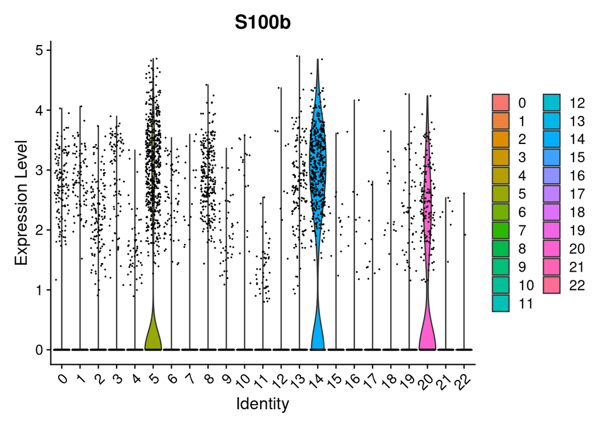

```r
# below are common astrocyte markers
vln_plot <- VlnPlot(mice.combined_joined, features = c("S100b"))

feature_plot <- FeaturePlot(mice.combined_joined, c('S100b'))

vln_plot
```

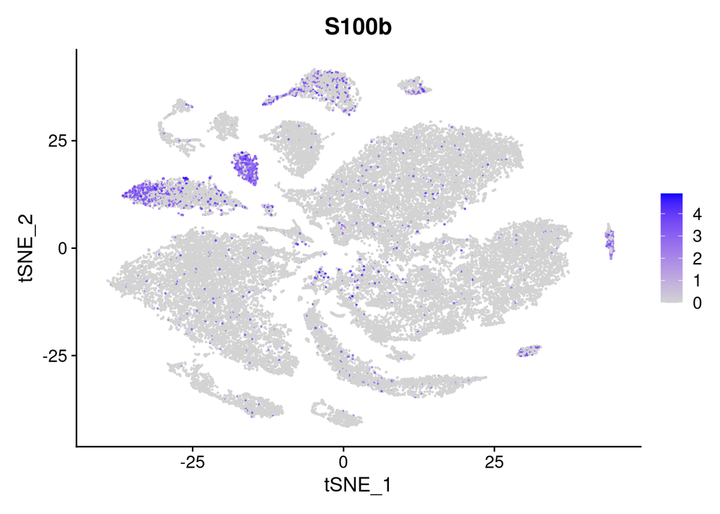

```r
feature_plot
```